# Practica 2

Enric Sintes Arguimbau i Carlos Romero Matarin

2024-06-04

# Descripció del dataset

El conjunt de dades amb el qual s’ha treballat en aquest document està compost per una col·lecció d’articles disponbiles en diferents supermercats, incloent-hi un conjunt de característiques associades a cada article. Per tant, és un dataset que pot cobrar una considerable importància en el sector del retail, ja que permet comparar les característiques i preus d’articles de diferents cadenes.

La importància d’aquest conjunt de dades rau en la seva capacitat per respondre a diverses preguntes que poden optimitzar les estratègies de negoci en aquest sector. Per altra banda, pot servir per millorar l’experiències del client a l’hora de fer la seva compra a, triant la cadèna de supermercats que més s’adeqüi a les necessitats de cada un, tant sigui pel preu de certs productes a cada una de les cadenes, pel surtit d’articles que hi ha o per les marques que es troben a cada una.  
Així doncs, els principals análisis que es poden fer de les dades son, classificació de productes, anàlisis de preus o comparació de marques.

El conjunt de dades inclou diverses variables que descriuen les característiques de cada producte:

- Nombre: descriptiu del producte.
- Marca: marca comercial del producte.
- Precio: preu de venta al públic.
- Supermercat: cadèna de supermercats al que pertany l’article.
- Hora: hora d’extracció de la dada.
- URL: direcció web on es troba l’article.
- Fecha: dia d’extracció.
- Hora: hora d’extracció.
- unidad: indica el tipus d’unitats amb el que es serveix producte.
- precio_unidad: preu per unitat en €.
- Categoria: secció de supermercat a la que pertany el producte. Tipus d’article.
- Subcategoria: subsecció de supermercat a la que pertany.
- Estado: disponibilitat de l’article al supermercat en questió.

Tot plegat comporta un conjunt de dades de 12 columnes i $25625$ files.

Aquest volum de dades permet un anàlisi detallada i comparativa de productes, cadenes de supermercats i marques.

# Integració i selecció

S’ha optat per modificar i ampliar el dataset original utilitzat a la Pràctica 1 per a l’activitat d’integració. El desig principal d’aquesta ampliació es proporcionar una base de dades més completa i detallada és allò que justifica aquesta decisió. Podem veure que aquest conjunt de dades es capaç de suportar anàlisis més profundes i variades sobre el comportament dels preus entre diferents cadenes de supermercats.

Dir que la limitació de la varietat i la profunditat de les dades inicials fa que calgui ampliar la les dades original. Com un exemple ràpid dir que hem millorat significativament la qualitat de l’anàlisi en afegir característiques com “Categoria”, “Subcategoria” i “Estat” als productes, cosa que permet segmentacions i comparacions més precises entre els productes. Podem dir que és especialment útil als estudis de mercat on la categorització dels productes pot afectar la percepció del preu i les decisions de compra dels consumidors.

Per fer l’ampliació del conjunt de dades i incloure noves variables com “Categoria”, “Subcategoria” i “Estado”, s’ha modificat el script original de Python utilitzat per a l’extracció de dades via web scraping. El que hem desenvolupat és que les modificacions recullin informació addicional de les pàgines de productes. El script actualitzat està disponible en el repositori GitHub del projecte.

Fem aquí la càrrega de les dades en el rmd i inicien les llibreries necessàries:

**Descripció del dataset:**

**Primeres Cinc Files:**

El quadre de dades comença amb una varietat d’articles, com detergents, lleixiu, maquinetes d’un sol ús, cera per a terra, etc. Aquesta primera mostra la varietat de productes disponibles al supermercat Consum, amb informació detallada sobre la marca, el preu i enllaços directes als productes, també podem veure com hi ha registres sense categoria.

```r
head(productos)
```

| Nombre | Marca | Precio | Supermercado | URL | Fecha | Hora | unidad | precio_unidad | Categoria | Subcategoria | Estado |
| --- | --- | --- | --- | --- | --- | --- | --- | --- | --- | --- | --- |
| Detergente Líquido Prendas Delicadas | PERLAN | 3,15 € | Consum | https://tienda.consum.es/es/p/detergente-liquido-prendas-delicadas/401356 | 2024-06-04 | 00:45:53 | 1 Lv | 0,13 € | NA | NA | Añadir |
| Lejía Multiusos | CONEJO | 2,69 € | Consum | https://tienda.consum.es/es/p/lejia-multiusos/419069 | 2024-06-04 | 00:45:56 | 1 L | 1,35 € | NA | NA | Añadir |
| Maquinilla Basculante Slalom Plus Desechable | GILLETTE | 2,89 € | Consum | https://tienda.consum.es/es/p/maquinilla-basculante-slalom-plus-desechable/423822 | 2024-06-04 | 00:45:57 | 1 U | 0,58 € | NA | NA | Añadir |
| Cera Suelos | ASEVI | 2,19 € | Consum | https://tienda.consum.es/es/p/cera-suelos/448852 | 2024-06-04 | 00:45:58 | 1 L | 2,19 € | NA | NA | Añadir |
| Antical Pastillas | CALGON | 8,99 € | Consum | https://tienda.consum.es/es/p/antical-pastillas/485565 | 2024-06-04 | 00:45:59 | 1 U | 0,60 € | NA | NA | Añadir |
| Filtros para Cafetera 1x4 | MELITTA | 2,45 € | Consum | https://tienda.consum.es/es/p/filtros-para-cafetera-1x4/612572 | 2024-06-04 | 00:46:00 | 1 U | 0,06 € | NA | NA | Añadir |

```r
#dim(productos)
```

**Descripció Estadística:**

Podem veure que hi ha 24.399 noms de producte diferents, destacant la diversitat i amplada d’assortiment disponible.

Dir que encara que la majoria de marques són identificables, un total de 2.711 productes són etiquetats com a “Marca no disponible”, reflectint possibles deficiències o inconsistències en la recopilació de dades. A més, 651 preus estan etiquetats com “no disponibles”, indicant que aquestes entrades poden necessitar una verificació o actualització de dades.

```r
describe(productos)
```

```
## productos
##
##  12  Variables      25625  Observations
## --------------------------------------------------------------------------------
## Nombre
##        n  missing distinct
##    25625        0    24399
##
## lowest : 100 Mejores Suplemento Alex Yañez             100% Real Whey Protein Cookies and Cream      25 Cuentos Clásicos Susaeta                   2Recambios Ambientador Automático Lavanda     30% Protein Bar Brownie 3 uds
## highest: Zumo Uva,Melocotón y Manzana Brik             Zumo Veggie Calabaza Zanahoria-Mango-Manza    Zumo Veggie Remolacha Frutos Bosque-Zanahoria Zumo+Leche Mediterráneo                       Zumo+Leche Tropical
## --------------------------------------------------------------------------------
## Marca
##        n  missing distinct
##    25159      466     3881
##
## lowest : 18/70       18/70 RUBIA 1880        1881        1906
## highest: ZERO        ZESPRI      ZIPPER      ZOCO        ZUM
## --------------------------------------------------------------------------------
## Precio
##        n  missing distinct
##    25625        0     2053
##
## lowest : 0,14 €               0,22 €               0,24 €               0,25 €               0,26 €
## highest: 9.99 €               95.75                99                   99,00 €              Precio no disponible
## --------------------------------------------------------------------------------
## Supermercado
##        n  missing distinct
##    25625        0        3
##
## Value                 Consum               Dia Supermercados Mas
## Frequency               8972              8840              7813
## Proportion             0.350             0.345             0.305
## --------------------------------------------------------------------------------
## URL
##        n  missing distinct
##    25625        0    25625
##
## lowest : https://tienda.consum.es/es/p/-cafe-extra-intenso-20-capsulas/7407695              https://tienda.consum.es/es/p/-guacamole/7145688                                   https://tienda.consum.es/es/p/100-mejores-suplemento-alex-yanez/7415375            https://tienda.consum.es/es/p/100-real-…
## highest: https://www.supermercadosmas.com/vino-rioja-tinto-resera-azpilicueta-reserva-75cl/ https://www.supermercadosmas.com/whisky-doble-v-70-cl-doble-v/                     https://www.supermercadosmas.com/yogur-fresa-yopro-p-2x-160gr/                     https://www.supermercadosmas.com/yogur-…
## --------------------------------------------------------------------------------
```

[output cut: 36 more lines]

```
## Subcategoria
##        n  missing distinct
##    16653     8972     7963
##
## lowest : Abono universal masso 1l                                 Abrillantador lavavajillas finish 500 ml                 Abrillantador lavavajillas ifa sabe 1 l                  Abrillantador lavavajillas limón finish 500 ml           Abrillantador somat 500 ml
## highest: Zumo refrigerado platano/coco/avena via nature bot 750ml Zumo refrigerado sin pulpa de naranja don simon 1l       Zumo tomate granini pet 1l                               Zumo tomate ifa eliges brik 1l                           Zumos
## --------------------------------------------------------------------------------
## Estado
##        n  missing distinct
##    25625        0        3
##
## Value                   Agotado               Añadir Estado no disponible
## Frequency                  2191                22939                  495
## Proportion                0.086                0.895                0.019
## --------------------------------------------------------------------------------
```

**Nombre de productes per supermercat:**

El gràfic mostra que el supermercat amb més productes registrats és “Consum” (8.972), seguit de prop per “Dia” (8.840) i “Supermercados Mas” (7.813). Segons aquesta distribució, “consum” i “dia” són els principals proveïdors de productes de la base de dades.

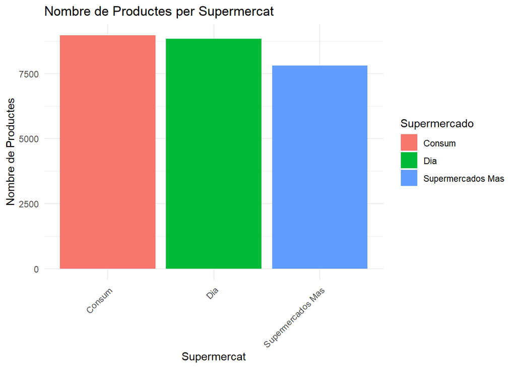

```r
# Calculamos el conteo de productos por supermercado
supercado_cuentas <- productos %>%
  count(Supermercado) %>%
  arrange(desc(n))  #

# Creación del gráfico de barras
ggplot(supercado_cuentas, aes(x = Supermercado, y = n, fill = Supermercado)) +
  geom_bar(stat = "identity") +  # 'identity' para usar los valores de 'n' directamente
  labs(title = "Nombre de Productes per Supermercat",
       x = "Supermercat",
       y = "Nombre de Productes") +
  theme_minimal() +  # Tema minimalista
  theme(axis.text.x = element_text(angle = 45, hjust = 1))
```

# Neteja de dades

## Valors faltants

En primer lloc s’ha identificat aquells valors de les variables que identifiquen valors faltants i s’ha trobat que a cada variable es registre un cadena de caràters que descriu que hi ha un valor faltant. Per exemple, a la variable `Nombre` s’han registrat els valors faltants com `Nombre no disponible`, a `Marca` `Marca no disponible`, i així successivament. Tots aquests valors s’han substituït per `NA` per poder tractar les variables correctament.

## Tipus de dades

A continuació, s’han corregit totes les variables que contenien caràcters especials i que no permeten tractar les variables així com és degut. Per exemple, la variable `Precio` conté el signe € i per tant no permet tractar la variable com un valor numèric. Llavors:

- `Nombre`: cadena de caràcters.
- `Precio`: s’ha extret el signe €, els espais que hi podria haver i s’ha canviat les , dels decials per punts `.`. D’aquesta manera s’ha pogut transformar la variable a numèric.
- `unidad`: s’ha convertit a factor i s’han unificat les categories que significaven el mateix. Per exemple: `1 U`, `Und.` i `UNIDAD` s’ha unificat a un sol nivell `UNIDAD`.
- `precio_unidad`: s’ha fet el mateix tractament que la variable `Precio` extraient signes i canviar les , dels decimals per punts. També s’ha trobat algún cas que s’utilitzava el `.` com a separadors del milers i també s’ha eliminat. Transformant posterior a valor numèric.
- `Marca`: variable categòrica, per tant s’ha trasnformat a factor.
- `Supermercat`: transformat a factor.
- `Hora`: variable de tipus temps.
- `Fecha`: variable de tipus data.
- `Caregoría`: vairable categòrica, per tant, factor.
- `Subcategoria`: conversió a factor.
- `Estado`: conversió a factor.

Un cop transformades les dades correctament, s’estudien altres tipus de valors que poden significar pèrdua de dades. Com per exemple, valors de la variable `Precio` o `precio_unitario` que tinguin valors 0 o negatius. Entre aquests s’han trobat dos casos que tenen un `precio_unidad` igual a 0, degut al valor tant reduït que té cada unitat d’aquests productes. Per evitar que aparegui el valor 0, es calcularà manualment el valor real dividint el preu per les unitats de cada article.

## Tractament de valors faltants

Un cop corregits els errors, hi ha que revistar i evaluar els valors faltants `NA` de cada una de les variables.

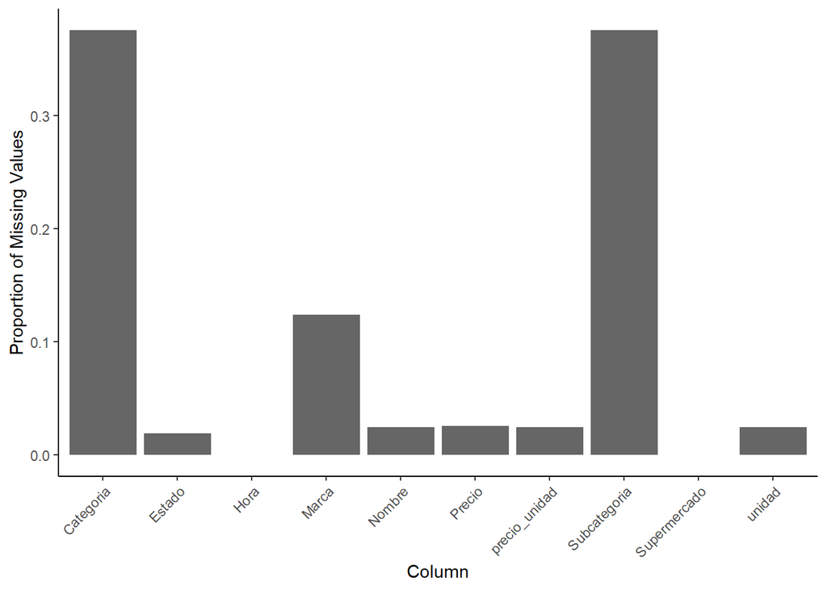

Les variables `Marca`, `Categoría` y `Subcategoría`, tenen una proporció de valors faltants elevats. És evident que si s’esborressin tots els casos faltants d’aquestes variables es perdrien molts casos i molta informació de valor per l’anàlisi posterior. Per tant, s’ha cercat una alternativa per evitar l’imputació de tots aquests valors. Aquesta alternativa consisteix en utilitzar un algoritme per completar les seccions faltants a partir del nom de cada producte. És a dir, a partir de les categories existents i dels noms dels productes d’aquestes categories, es fa una estimació de quina categoria pot ser la més adecuada per cada article li falta aquest valor. Exactament, el que es fa és, per un producte sense categoria i subcategoria, cercar els productes amb categoria i subcategoria conegudes amb més paraules coincidents i assigna la categoria i subcategoria més freqüents. Així i tot, hi ha productes que no s’ha pogut classificar correctament, però tot i així s’ha reduït considerablement els valors faltants.

Respecte a les altres variables es ronda un 2% de valors faltants i possiblament siguin els mateixos casos. Per tant, imputarem tots els valors que no tenen un registre ni a la varaibles `Nombre`, `Precio`, `unidad` ni `precio_unidad`, ja que no aporten cap valor analític. Aquests casos signifiquen exactament 0.0244 de les files.

Per les dades que no tenen categoria ni subcategoria hem dit de donar-los un valor fem una relació d’aquest registre per un nom semblant en altres registres de cara a tenir un valor “estimat” d’aquestes dues variables, graciés a l’ajuda dels altres registres.

```r
# Faltantes por supermercado
table(productos_actualizados$Supermercado, is.na(productos_actualizados$Categoria)) %>% prop.table(margin = 2)
```

```
##
##                         FALSE      TRUE
##   Consum            0.3576066 1.0000000
##   Dia               0.3292722 0.0000000
##   Supermercados Mas 0.3131212 0.0000000
```

```r
# Faltantes por supermercado
table(productos_actualizados$Supermercado, is.na(productos_actualizados$Subcategoria)) %>% prop.table(margin = 2)
```

```
##
##                         FALSE      TRUE
##   Consum            0.3576066 1.0000000
##   Dia               0.3292722 0.0000000
##   Supermercados Mas 0.3131212 0.0000000
```

## Valors extrems

Per estudiar els valors extrems s’estudien els valors numèrics i estudiarem els valors que poden distorsionar els estudis analítics. Aquesta variable és: `Precio`.

El primer pas és estudiar la seva distribució, que es pot valorar tant amb un diagrama de barres com amb un boxplot, que és on es veuen millor els outliers.

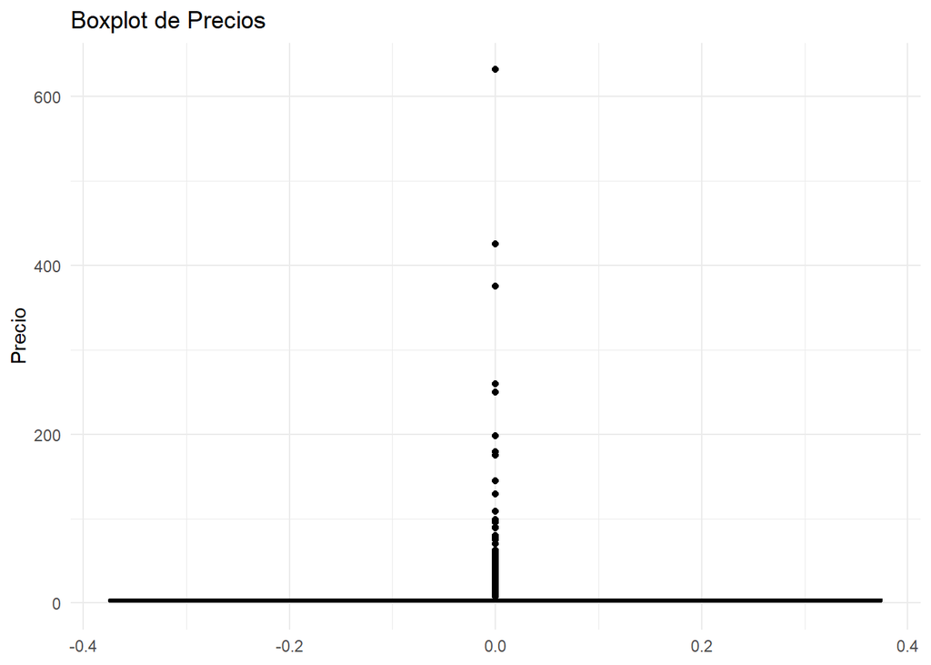

Es pot veure com la variable `Precios` sí té valors extrems que poden distorsionar les dades.

Un cop visualitzats els valors extrems, els podem detectar considerant que un outlier son tots els punts que es troben a una distància del primer o tercer quartil, més gran que 1.5 cops el rang interquantílic. D’aquesta manera, al tenir identificats els valors extrems, podem eliminar-los.

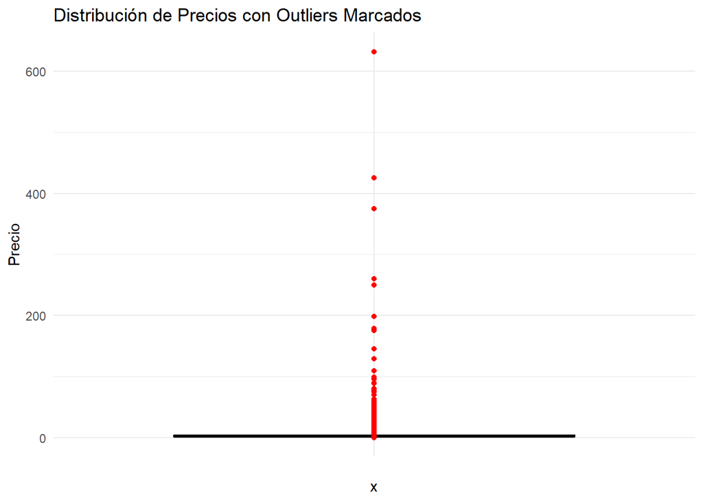

En total s’han trobat 2603 del quals es reparteixen entre els supermercats de la següent manera:

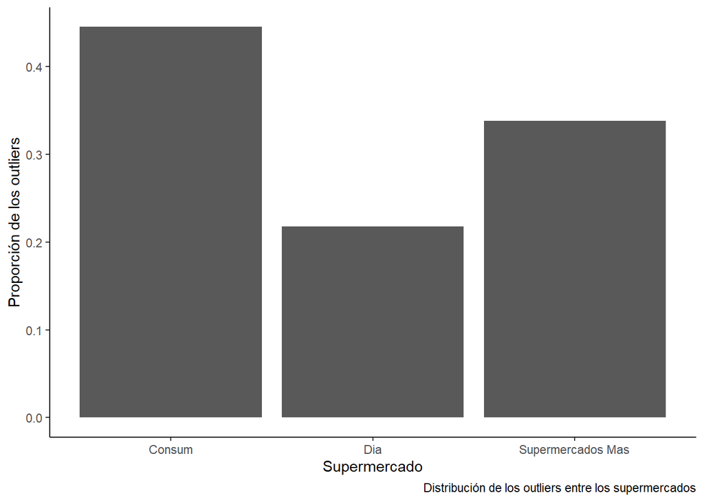

Per tant, es por veure que quasi la meitat dels outliers trobats es troben en el supermercat Consum, mentre que a Dia, és on hi ha menys freqüència de outliers. Això no vol dir que Consum sigui el supermercat més car, sinó que té més articles de preu elevat.

Tot i així, resvisant els valors extrems, considerem que no és necessari corregir ni eliminar-los, ja que no es tracten d’errors d’entrada, sinó que es tracta d’articles de més alta qualitat que tenen un preu alt, però formen part de l’assortiment normal d’un supermercat. Així doncs, formaràn part de les dades a analitzar.

## Representació variables

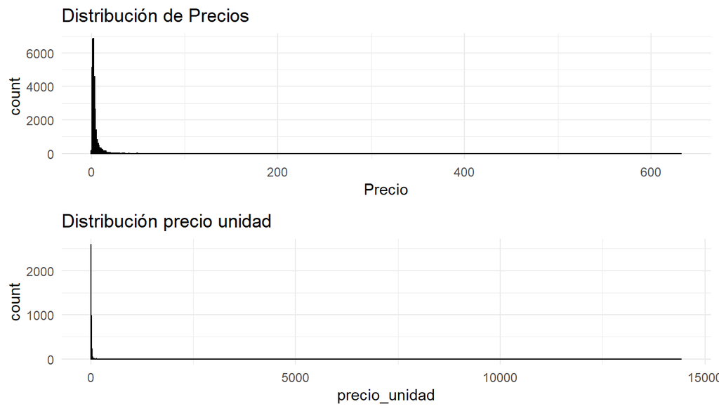

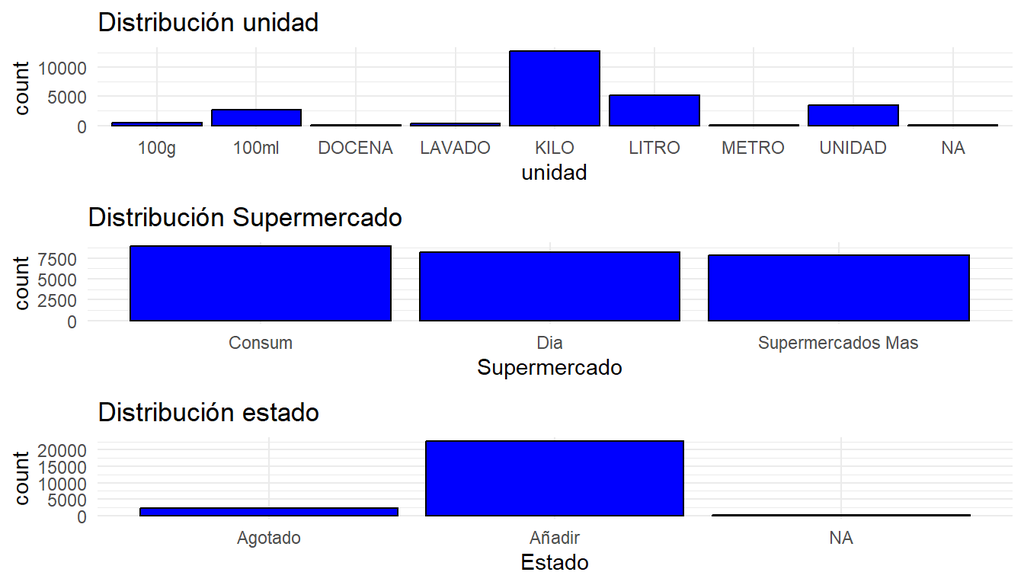

[figure not shown]

# Anàlisi de les dades

## Models

### Model supervisat

Basant-nos en les variables de unitat i supermercat, hem utilitzat un model de regressió lineal per predir el preu del producte a la secció de modelització supervisada. El model que hem definit cerca comprendre com aquests elements afecten el preu final del producte. Per si de cas s’ha eliminat la variable Preu els caràcters especials (€) i s’ha convertit de text a numèric.

```r
# Asegurando que las variables están en formato adecuado
productos$Precio <- as.numeric(gsub(" €", "", gsub(",", ".", productos$Precio)))

# Modelo de regresión lineal donde predecimos 'Precio' basado en otras características:
modelo_lineal <- lm(Precio ~ unidad + Supermercado, data = productos_actualizados)
summary(modelo_lineal)
```

```
##
## Call:
## lm(formula = Precio ~ unidad + Supermercado, data = productos_actualizados)
##
## Residuals:
##    Min     1Q Median     3Q    Max
##  -6.08  -2.30  -1.16   0.28 628.07
##
## Coefficients:
##                               Estimate Std. Error t value Pr(>|t|)
## (Intercept)                     2.2493     0.3941   5.707 1.16e-08 ***
## unidad100ml                     3.3384     0.4216   7.919 2.50e-15 ***
## unidadDOCENA                    0.3366     1.3330   0.253  0.80064
## unidadLAVADO                    4.3098     0.5772   7.466 8.53e-14 ***
## unidadKILO                      1.3068     0.3974   3.288  0.00101 **
## unidadLITRO                     2.5454     0.4066   6.260 3.92e-10 ***
## unidadMETRO                     0.4068     1.6586   0.245  0.80627
## unidadUNIDAD                    2.5403     0.4137   6.140 8.38e-10 ***
## SupermercadoDia                -0.8466     0.1236  -6.848 7.66e-12 ***
## SupermercadoSupermercados Mas   0.3721     0.1255   2.964  0.00304 **
## ---
## Signif. codes:  0 '***' 0.001 '**' 0.01 '*' 0.05 '.' 0.1 ' ' 1
##
## Residual standard error: 8.059 on 24957 degrees of freedom
##   (34 observations deleted due to missingness)
## Multiple R-squared:  0.01406,    Adjusted R-squared:  0.01371
## F-statistic: 39.56 on 9 and 24957 DF,  p-value: < 2.2e-16
```

Els resultats obtinguts ens indiquen que diferents unitats i els supermercats tenen un impacte estadísticament significatiu sobre el preu. Per exemple, els coeficients per a les unitats com ‘100ml’ i ‘LAVADO’ mostren increments notables en els preus, cosa que suggeriria que aquestes unitats tendeixen a estar associades amb preus més alts.

Cal dir que , els supermercats també juguen un paper crucial en la determinació dels preus. En particular, els productes del supermercat Dia tendeixen a ser més barats en comparació amb la base. Aquest fet es reflecteix en el coeficient negatiu per a Dia. En contrast, els Supermercats Mas mostren un petit increment en els preus comparat amb el supermercat de referència.

Podem veure que rl model té un R-quadrat ajustat relativament baix, cosa que indica que les variables incloses expliquen només una petita part de la variabilitat dels preus dels productes.

### Model no supervisat

Hem desarrollat l’algorisme k-means per agrupar els productes en funció dels seus preus i preus per unitat per a l’anàlisi no supervisada. Primer per si de cas els preus s’han netejat i convertit en un format numèric. Despues l’agrupació esta definida en tres grups.

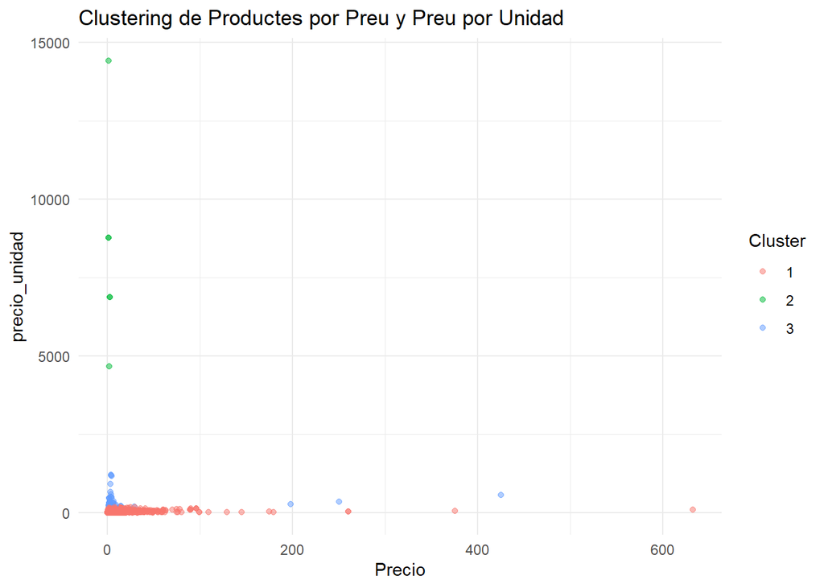

```r
productos$Precio <- as.numeric(gsub(" €", "", gsub(",", ".", productos$Precio)))
productos$precio_unidad <- as.numeric(gsub("€", "", gsub(",", ".", productos$precio_unidad)))

productos <- productos %>%
  filter(!is.na(Precio) & !is.na(precio_unidad) &
         !is.nan(Precio) & !is.nan(precio_unidad) &
         Precio != Inf & Precio != -Inf &
         precio_unidad != Inf & precio_unidad != -Inf)

set.seed(123)

# Ejecutar k-means con 3 centros
kmeans_resultado <- kmeans(productos[, c("Precio", "precio_unidad")], centers = 3)

# Agregar los clusters al dataframe para análisis posterior
productos$Cluster <- as.factor(kmeans_resultado$cluster)

# Visualizar los resultados de k-means

ggplot(productos, aes(x = Precio, y = precio_unidad, color = Cluster)) +
  geom_point(alpha = 0.5) +
  labs(title = "Clustering de Productes por Preu y Preu por Unidad") +
  theme_minimal()
```

## Prueba de Contraste de Hipótesis

Hem dut a terme una prova de contrast d’hipòtesis, enfocant-te específicament en els que contenien “Jamon” en nom seu. El procés inclou la neteja de dades, la conversió del preu de text a números i la creació d’una variable per determinar si el producte conté “Jamon” en el nom.

```r
productos$Precio <- as.numeric(gsub(" €", "", gsub(",", ".", productos$Precio)))  # Limpieza de datos

# Agregamos una nueva columna para identificar si el nombre del producto contiene 'Jamon'
productos <- productos %>%
  mutate(contiene_Jamon = ifelse(grepl("Jamon", Nombre, ignore.case = TRUE), "Con Jamon", "Sin Jamon"))

# Calculamos el precio medio general excluyendo NA
precio_medio_general <- mean(productos$Precio, na.rm = TRUE)

# Subconjunto de productos que contienen 'Jamon' en el nombre
productos_con_Jamon <- productos %>%
  filter(contiene_Jamon == "Con Jamon") %>%
  pull(Precio)

# Prueba de normalidad
shapiro_test_Jamon <- shapiro.test(productos_con_Jamon)
print(shapiro_test_Jamon)
```

```
##
##  Shapiro-Wilk normality test
##
## data:  productos_con_Jamon
## W = 0.35624, p-value < 2.2e-16
```

```r
# Dependiendo de la normalidad, realizar t-test o Wilcoxon test
if (shapiro_test_Jamon$p.value > 0.05) {
  t_test_result <- t.test(productos_con_Jamon, mu = precio_medio_general)
  print(t_test_result)
} else {
  print("Distribución no normal, aplicando prueba no paramétrica.")
  wilcox_test_result <- wilcox.test(productos_con_Jamon, mu = precio_medio_general, alternative = "greater")
  print(wilcox_test_result)
}
```

```
## [1] "Distribución no normal, aplicando prueba no paramétrica."
##
##  Wilcoxon signed rank test with continuity correction
##
## data:  productos_con_Jamon
## V = 844, p-value = 0.9989
## alternative hypothesis: true location is greater than 4.055195
```

# Resolució del problema:

# Codi

El codi font desenvolupat per a la neteja, anàlisi i representació de dades ha estat principalment desenvolupat en R. Ja escollit per la seva flexibilitat, poder estadístic i la disponibilitat d’una àmplia biblioteca de paquets específics per a la manipulació de dades i visualització gràfica.

En elcodi en R hem utilitzat diverses llibreries crucials per al processament i anàlisi de dades com dplyr per a la manipulació de dades, ggplot2 per a la visualització, i readr per a la càrrega eficient de dades. Dir que per la neteja de dades, s’han implementat rutines específiques que tracten amb valors faltants, correcció de formats i la normalització de les cadenes de text. Aquestes tasques són necessàries per assegurar la qualitat i la consistència dels conjunts de dades amb els quals s’analitzen.

Podem veure també que en el codi per a l’anàlisi de les dades hem desenvolupat models estadístics com regressions lineals i algoritmes de clustering (k-means). Méstard hem fet les visualitzacions dels resultats d’anàlisis en difuntes tipus de gràfics.

Dir que el codi font està disponible de manera pública en el següent enllaç del repositori GitHub, que conté tots els scripts utilitzats així com documentació addicional sobre l’estructura i l’ús dels codis:

https://github.com/cromeroUOC/Analysis-Web-Scraping-Supermarket

# Referències

- RPubs - Clase 6 - Limpieza de datos. (n.d.). https://rpubs.com/camilamila/limpieza
- kmeans function - RDocumentation. (n.d.). https://www.rdocumentation.org/packages/stats/versions/3.6.2/topics/kmeans
- RPubs - Introducción a los Modelos de Agrupamiento en R. (n.d.). https://rpubs.com/rdelgado/399475
- RPubs - Regresión lineal simple. (n.d.). https://rpubs.com/joser/RegresionSimple
- RPubs - Market Basket Analysis on Groceries Data. (n.d.). https://rpubs.com/Handedemirci/1011420

# Taula de Contribucions

Resum de Contribucions

| Contribucions | Signatura |
| --- | --- |
| Investigació prèvia | CRM, ESA |
| Redacció de les respostes | CRM, ESA |
| Desenvolupament del codi | CRM, ESA |
| Participació al vídeo | CRM, ESA |

CRM: Carlos Romero Matarin ESA: Enric Sintes Arguimbau